# Aspen specific sequences blast results

Nicolas Delhomme

2018-05-22

# 1 Setup

Set the working dir

```r
setwd("/mnt/picea/projects/aspseq/asp201/rna/BLAST")
```

- Libraries

```r
suppressPackageStartupMessages(library(LSD))
suppressPackageStartupMessages(library(RColorBrewer))
suppressPackageStartupMessages(library(VennDiagram))
```

- Helper functions

```r
suppressPackageStartupMessages(source("~/Git/UPSCb/src/R/blastUtilities.R"))
suppressPackageStartupMessages(source("~/Git/UPSCb/src/R/plot.multidensity.R"))
```

- Palette

```r
pal <- brewer.pal(8,"Dark2")
```

- Function

```r
"report" <- function(file,query,subject){
  suppressWarnings(blt <- readBlast(file=file,
                                    format = BM8ext,plot = FALSE,bestHit = TRUE,
                                    ignoreSelf = TRUE,verbose=FALSE))

  plot(density(blt$blf$percent.identity),
       main=paste(query,"mRNA aligned to the",subject),
       sub="percent identity",col=pal[1],lwd=2)

  comparisonplot(blt$df$query.cum.cov,blt$df$subject.cum.cov,
                 xlab=query,ylab=subject,
                 main="reciprocal cumulative coverage")

  return(list(r7=blt$df$query.id[blt$df$query.cum.cov >= 0.7 & blt$df$subject.cum.cov >= 0.7],
           r3=blt$df$query.id[blt$df$query.cum.cov >= 0.3 & blt$df$subject.cum.cov >= 0.3],
           u7=blt$df$query.id[blt$df$subject.cum.cov >= 0.7],
           u3=blt$df$query.id[blt$df$subject.cum.cov >= 0.3]))
}
```

# 2 BLAST results

## 2.1 Potra01

### 2.1.1 mRNA

- The percentage identity of the HSPs is quite high
- But most mRNA have only very partial high homology to nt sequences (in terms of coverage of the mRNA extent)

```r
potra01.mRNA <- report("nt_Potra01-Potr-specific-mRNA.blt",
               "Potra01","NCBI nt")
```

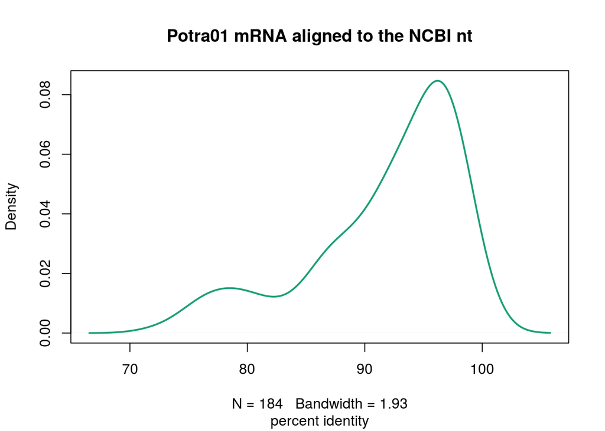

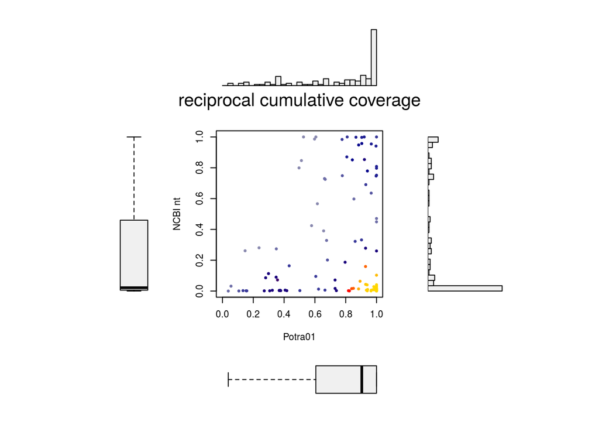

A brief Summary

- Number of reciprocal hits with >= 70% coverage

```r
length(potra01.mRNA$r7)
```

```
## [1] 19
```

- Number of reciprocal hits with >= 30% coverage

```r
length(potra01.mRNA$r3)
```

```
## [1] 37
```

- Number of mRNA with >= 70% coverage

```r
length(potra01.mRNA$u7)
```

```
## [1] 26
```

- Number of mRNA hits with >= 30% coverage

```r
length(potra01.mRNA$u3)
```

```
## [1] 37
```

### 2.1.2 protein

- The percentage identity of the protein is quite high, around 50%.
- But as previously, most protein have high homology to a limited extent of the protein length, albeit almost all the query protein have a full match

```r
potra01.protein <- report("uniref90_Potra01-Potr-specific-protein.blt",
                       "Potra01","UniRef90")
```

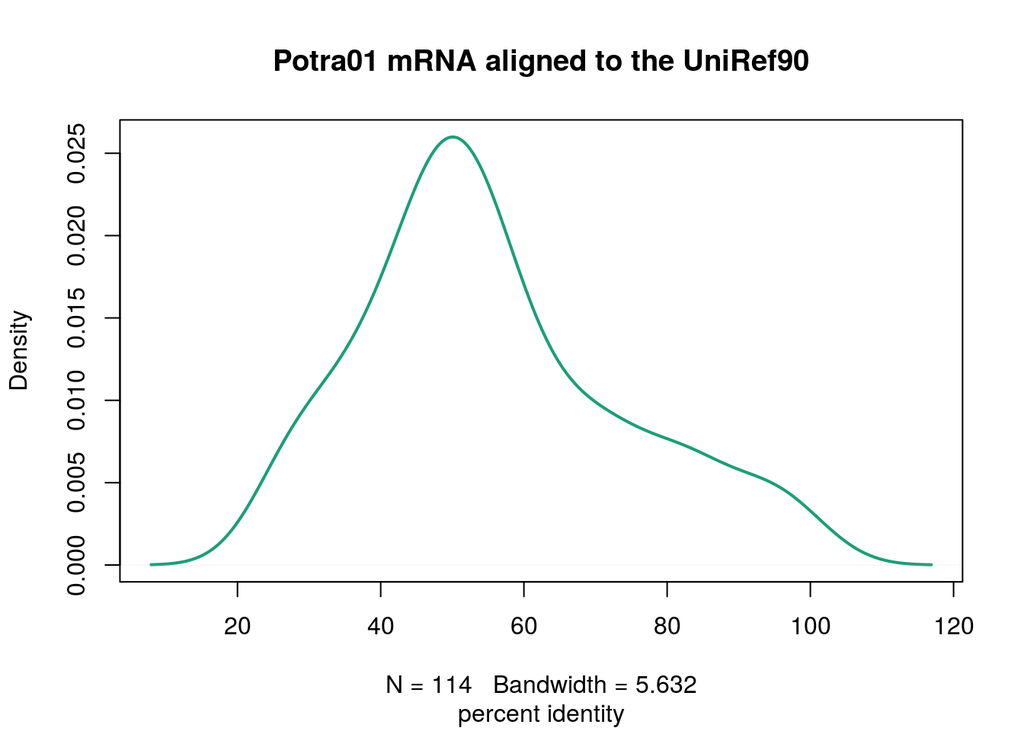

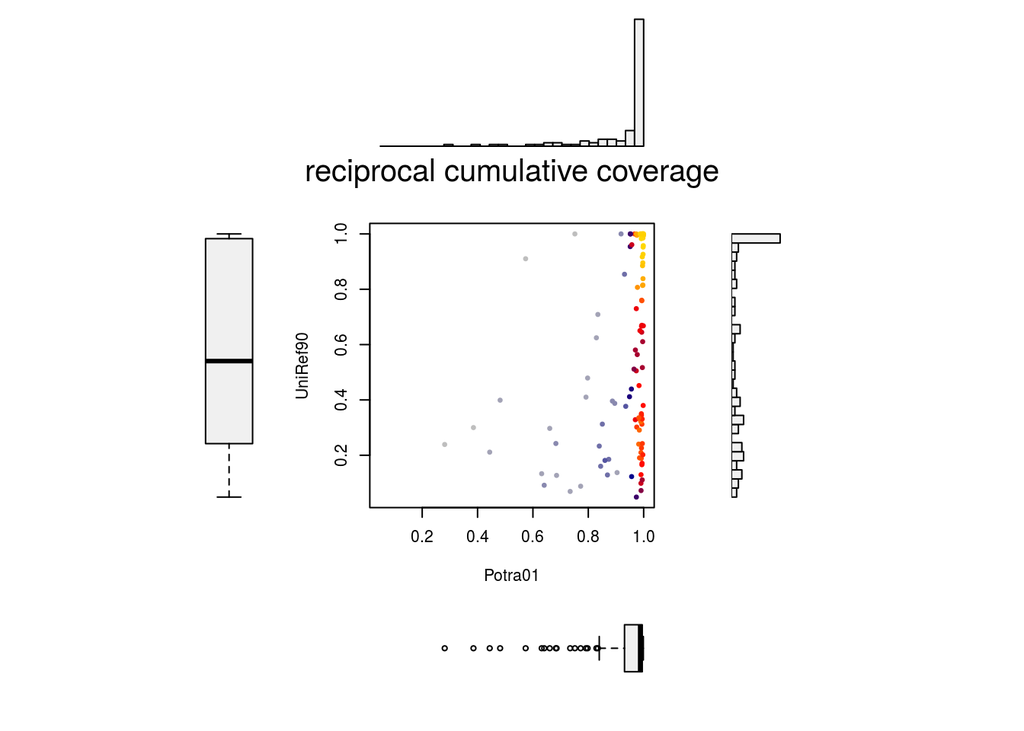

A brief Summary

- Number of reciprocal hits with >= 70% coverage

```r
length(potra01.protein$r7)
```

```
## [1] 45
```

- Number of reciprocal hits with >= 30% coverage

```r
length(potra01.protein$r3)
```

```
## [1] 79
```

- Number of mRNA with >= 70% coverage

```r
length(potra01.protein$u7)
```

```
## [1] 46
```

- Number of mRNA hits with >= 30% coverage

```r
length(potra01.protein$u3)
```

```
## [1] 79
```

### 2.1.3 Comparison

- Reciprocal 70%

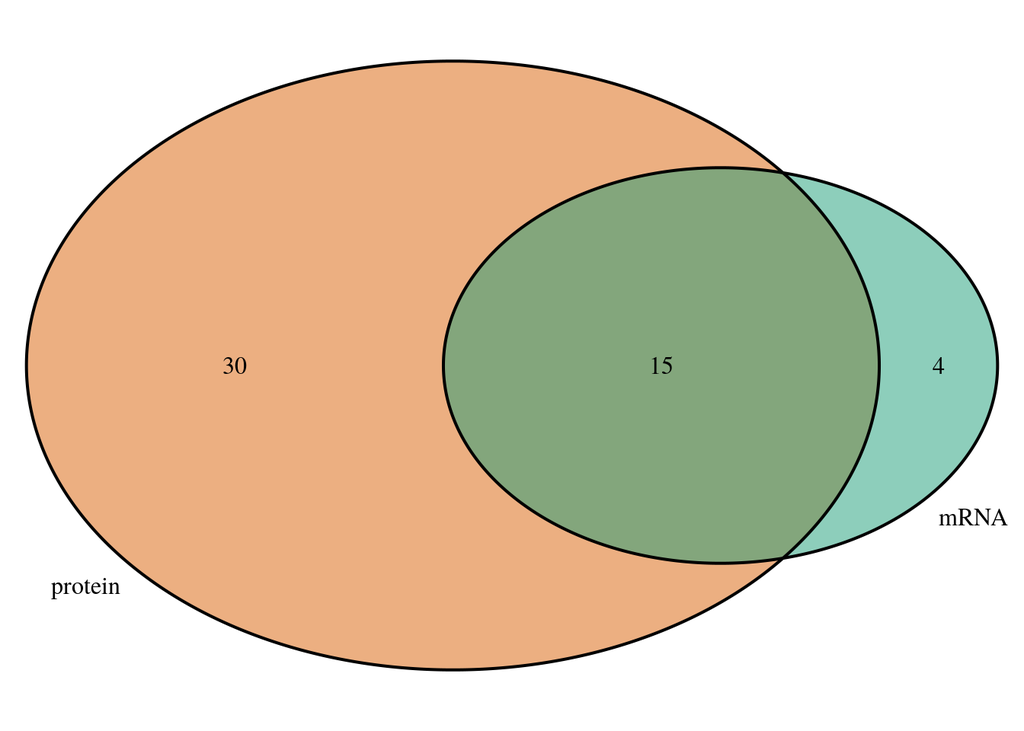

```r
plot.new()
grid.draw(venn.diagram(list(mRNA=potra01.mRNA$r7,
                            protein=potra01.protein$r7),
                       filename = NULL,fill=pal[1:2]))
```

- Reciprocal 30%

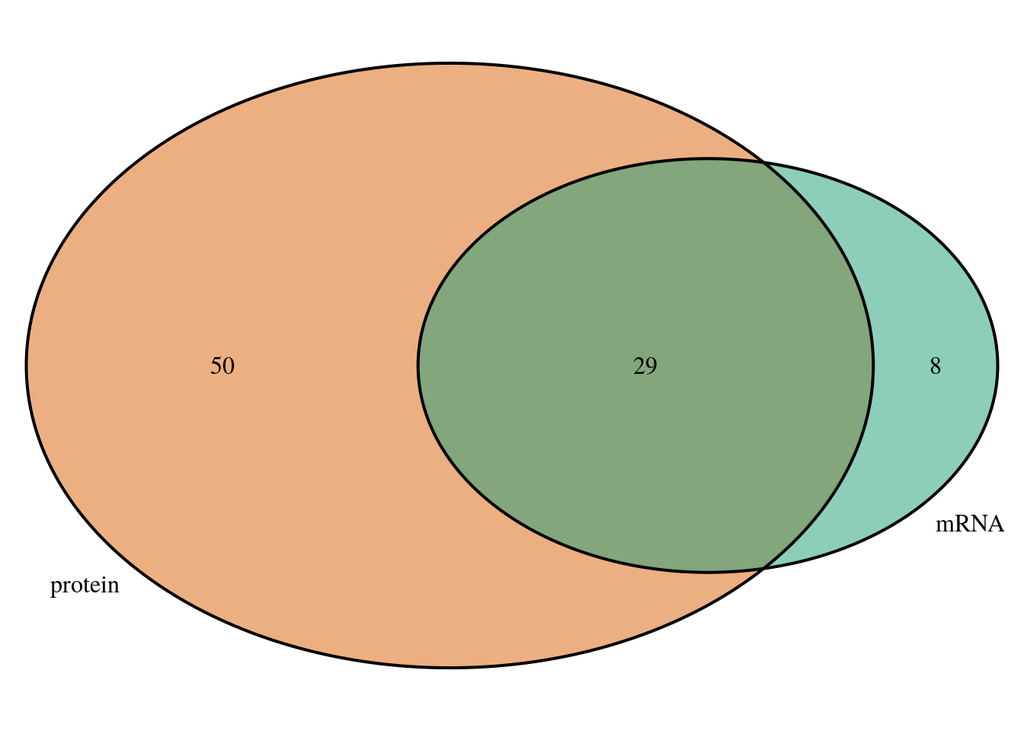

```r
plot.new()
grid.draw(venn.diagram(list(mRNA=potra01.mRNA$r3,
                            protein=potra01.protein$r3),
                       filename = NULL,fill=pal[1:2]))
```

- Unique 70%

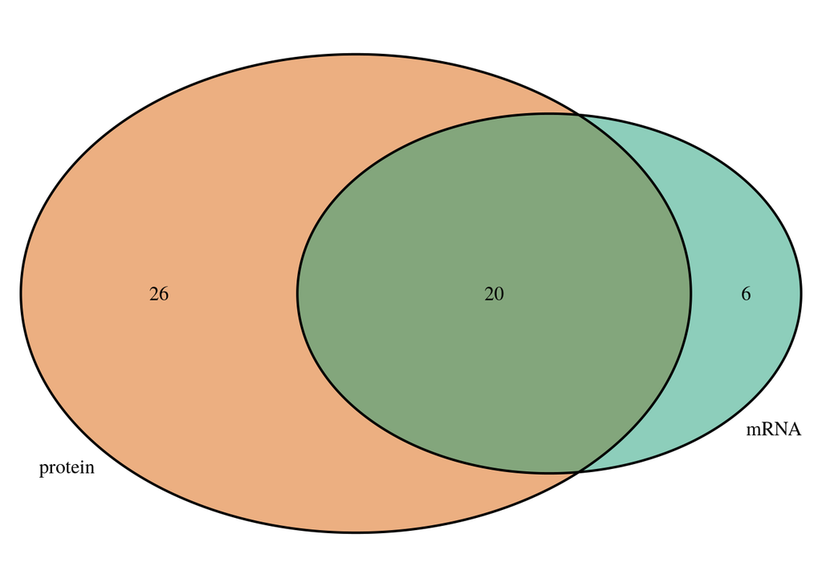

```r
plot.new()
grid.draw(venn.diagram(list(mRNA=potra01.mRNA$u7,
                            protein=potra01.protein$u7),
                       filename = NULL,fill=pal[1:2]))
```

- Unique 30%

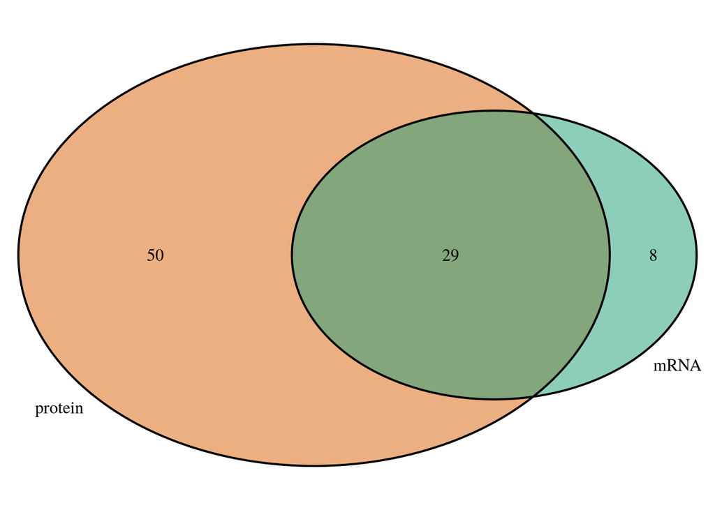

```r
plot.new()
grid.draw(venn.diagram(list(mRNA=potra01.mRNA$u3,
                            protein=potra01.protein$u3),
                       filename = NULL,fill=pal[1:2]))
```

## 2.2 Potrs01

### 2.2.1 mRNA

- The percentage identity of the HSPs is quite high
- But most mRNA have only very partial high homology to nt sequences (in terms of coverage of the mRNA extent)

```r
potrs01.mRNA <- report("nt_Potrs01-Potr-specific-mRNA.blt",
                       "Potrs01","NCBI nt")
```

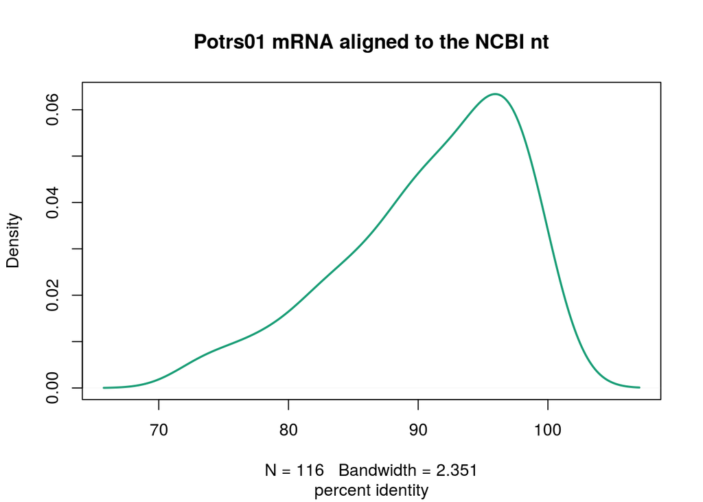

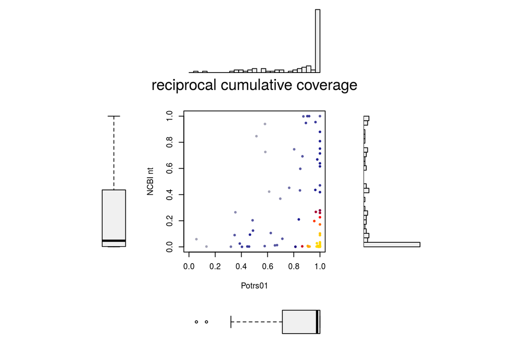

A brief Summary

- Number of reciprocal hits with >= 70% coverage

```r
length(potrs01.mRNA$r7)
```

```
## [1] 11
```

- Number of reciprocal hits with >= 30% coverage

```r
length(potrs01.mRNA$r3)
```

```
## [1] 26
```

- Number of mRNA with >= 70% coverage

```r
length(potrs01.mRNA$u7)
```

```
## [1] 14
```

- Number of mRNA hits with >= 30% coverage

```r
length(potrs01.mRNA$u3)
```

```
## [1] 26
```

### 2.2.2 protein

- The percentage identity of the protein is quite high, around 50%.
- But as previously, most protein have high homology to a limited extent of the protein length, albeit almost all the query protein have a full match

```r
potrs01.protein <- report("uniref90_Potrs01-Potr-specific-protein.blt",
                          "Potrs01","UniRef90")
```

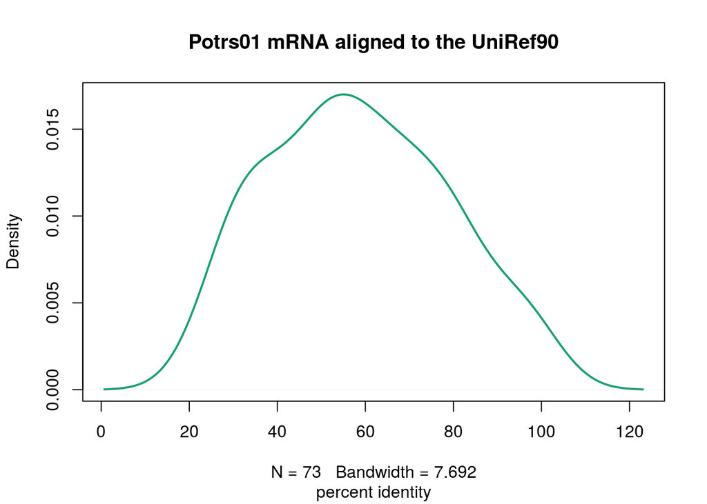

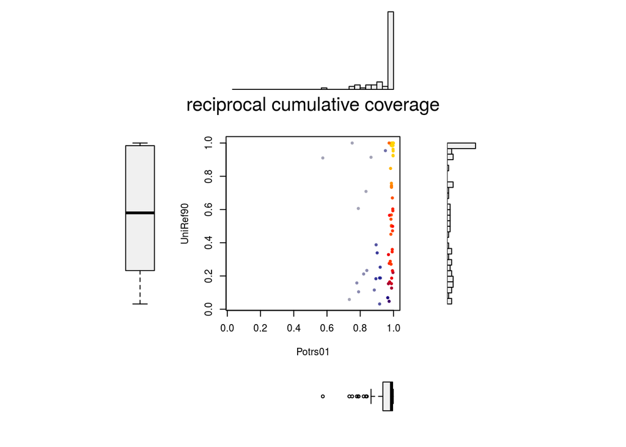

A brief Summary

- Number of reciprocal hits with >= 70% coverage

```r
length(potrs01.protein$r7)
```

```
## [1] 31
```

- Number of reciprocal hits with >= 30% coverage

```r
length(potrs01.protein$r3)
```

```
## [1] 49
```

- Number of mRNA with >= 70% coverage

```r
length(potrs01.protein$u7)
```

```
## [1] 32
```

- Number of mRNA hits with >= 30% coverage

```r
length(potrs01.protein$u3)
```

```
## [1] 49
```

### 2.2.3 Comparison

- Reciprocal 70%

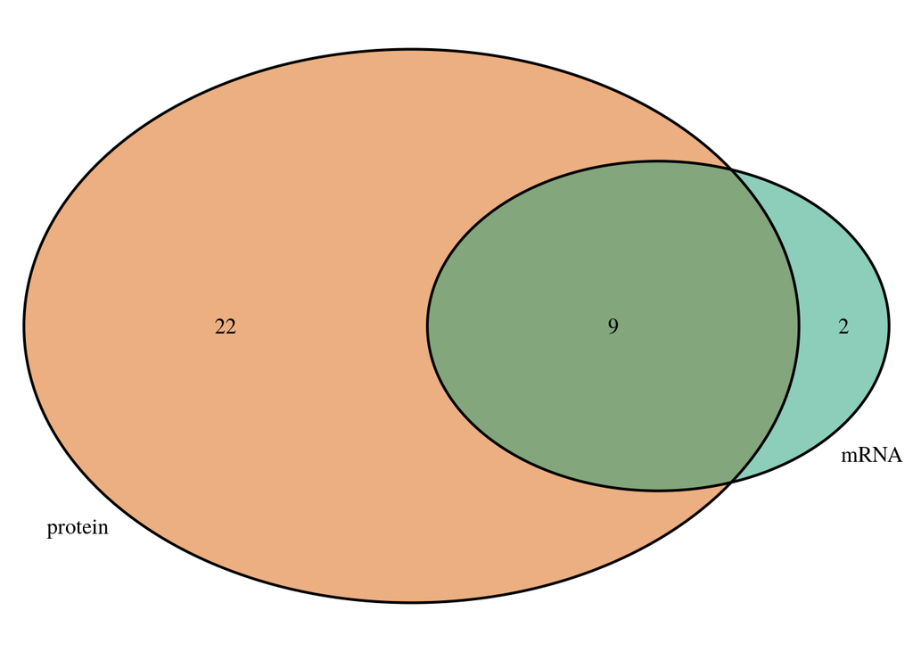

```r
plot.new()
grid.draw(venn.diagram(list(mRNA=potrs01.mRNA$r7,
                            protein=potrs01.protein$r7),
                       filename = NULL,fill=pal[1:2]))
```

- Reciprocal 30%

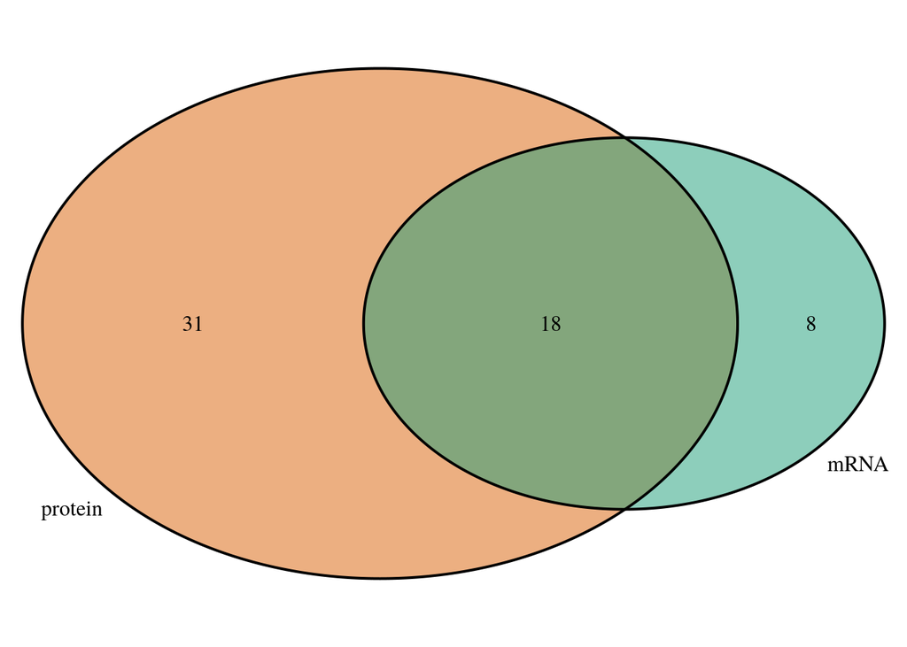

```r
plot.new()
grid.draw(venn.diagram(list(mRNA=potrs01.mRNA$r3,
                            protein=potrs01.protein$r3),
                       filename = NULL,fill=pal[1:2]))
```

- Unique 70%

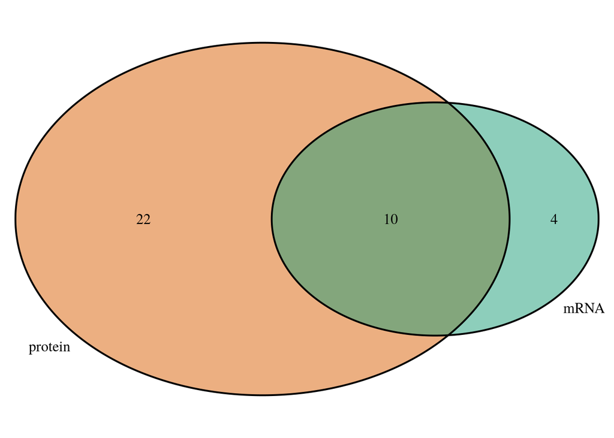

```r
plot.new()
grid.draw(venn.diagram(list(mRNA=potrs01.mRNA$u7,
                            protein=potrs01.protein$u7),
                       filename = NULL,fill=pal[1:2]))
```

- Unique 30%

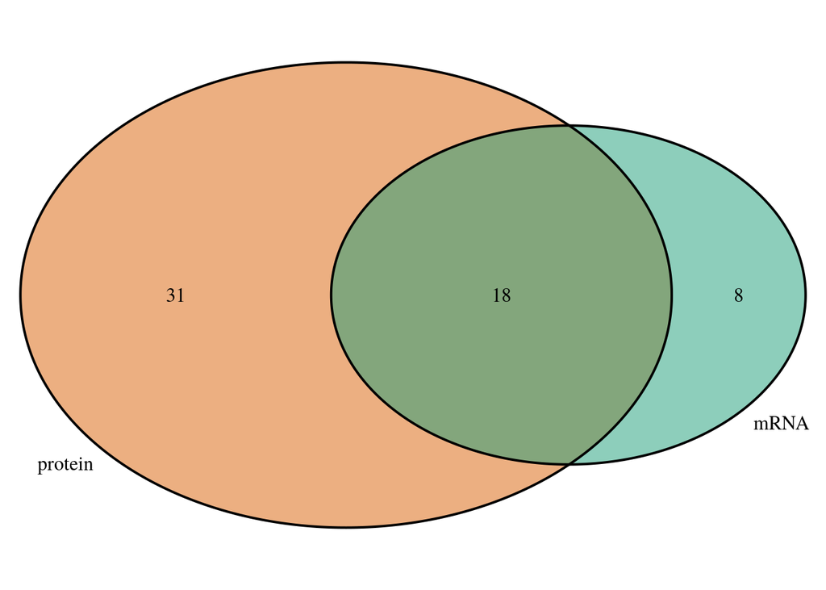

```r
plot.new()
grid.draw(venn.diagram(list(mRNA=potrs01.mRNA$u3,
                            protein=potrs01.protein$u3),
                       filename = NULL,fill=pal[1:2]))
```